# Lecture #23: The Fundamental Theorem of Calculus

MATH 145 – Calculus I

Torin Quinlivan

tquinlivan@knox.edu

Knox College

November 6, 2025

## Velocity and Distance

Suppose $v(t)$ is the velocity of an object of an object at time $t$ and consider the distance traveled over the time interval $\Delta t$.

$$\begin{aligned}
\int_a^b v(t) \, dt &= \lim\limits_{n \to \infty} \sum_{i = 1}^n v(t_i) \Delta t \\
&= \textrm{distance traveled (displacement)} \\
&= \textrm{area under the graph of } v(t) \\
&= f(b) - f(a)
\end{aligned}$$

## The Fundamental Theorem of Calculus

Suppose $f(t)$ is a continuous function on the interval $[a, b]$ and that $F(t)$ is an antiderivative of $f(t)$. Then

$$\int_a^b f(t) \, dt = F(b) - F(a)$$

## The Fundamental Theorem of Calculus

**Notes:**

This makes evaluating definite integrals easy, *provided you can find an antiderivative*.

Alternatively, $\displaystyle\int_a^b f'(t) \, dt = f(b) - f(a)$.

Also, $F(b) = F(a) + \displaystyle\int_a^b f(t) \, dt$.

## Example: The Fundamental Theorem of Calculus

**Example:** At 10 a.m. A cistern at a rate of $R(t) \, \frac{gallons}{hour}$, where $R(t)$ has the graph given below.

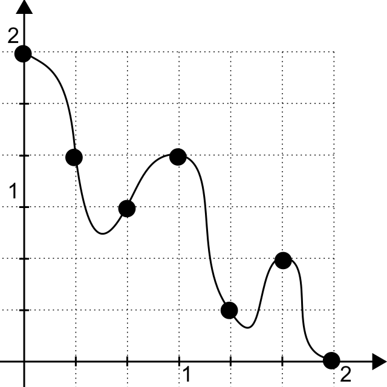

Estimate the amount of water in the tank at noon.

## Example: The Fundamental Theorem of Calculus

**Examples:**

1. Find $\displaystyle\int_0^2 3x+1 \, dx$.
2. Find $\displaystyle\int_1^3 (x-1)^2 \, dx$.
3. Find $\displaystyle\int_0^{\frac{\pi}{2}} \sin(x) \, dx$.
4. Find $\displaystyle\int_0^3 e^x \, dx$.
5. Find $\displaystyle\int_0^{\pi} \cos(x) + \dfrac{1}{\sqrt{1 - x^2}} \, dx$.

## Some Theorems for Definite Integrals

**Theorem:** $\displaystyle\int_a^b c \cdot f(x) + d \cdot g(x) \, dx = c \displaystyle\int_a^b f(x) \, dx + d \displaystyle\int_a^b g(x) \, dx$.

**Theorem:** If $a < c < b$, $\displaystyle\int_a^b f(x) \, dx = \displaystyle\int_a^c f(x) \, dx + \displaystyle\int_c^b f(x) \, dx$.

**Note:** There is no product or quotient rule for definite integrals, at least not directly. (Take Calc II to learn more!)

## The Fundamental Theorem of Calculus

Every continuous function $f(x)$ has an antiderivative.

If $f(x)$ is a continuous function on an interval and $a$ is any point, then the function:

$$F(x) = \int_a^x f(t) \, dt,$$

is an antiderivative of $f(x)$.

## The Fundamental Theorem of Calculus

If $f(x)$ is a continuous function on an interval and $a$ is any point, then the function:

$$F(x) = \int_a^x f(t) \, dt,$$

is an antiderivative of $f(x)$.

In other words:

$$\frac{d}{dx} \left[ \int_a^x f(t) \, dt \right] = f(x).$$